# Project Capstone 1

#Introduction

The goal of this project is just to display that you’ve gotten used to working with the data and that you are on track to create your prediction algorithm. Please submit a report on R Pubs (http://rpubs.com/) that explains your exploratory analysis and your goals for the eventual app and algorithm. This document should be concise and explain only the major features of the data you have identified and briefly summarize your plans for creating the prediction algorithm and Shiny app in a way that would be understandable to a non-data scientist manager. You should make use of tables and plots to illustrate important summaries of the data set. The motivation for this project is to:

1. Demonstrate that you’ve downloaded the data and have successfully loaded it in.
2. Create a basic report of summary statistics about the data sets.
3. Report any interesting findings that you amassed so far.
4. Get feedback on your plans for creating a prediction algorithm and Shiny app.

# Loading Data

Loading data from the already downloaded files on the disk

```r
Blogs <- suppressWarnings(readLines("./data/en_US/en_US.blogs.txt", skipNul = TRUE, encoding = "UTF-8"))
Twitter <- suppressWarnings(readLines("data/en_US/en_US.twitter.txt", skipNul = TRUE, encoding = "UTF-8"))
News <- suppressWarnings(readLines("data/en_US/en_US.news.txt", skipNul = TRUE, encoding = "UTF-8"))
```

# Data summary

## Blog

Displaying first 5 elements and number of summary of data set including number of lines, number of character etc.

```r
head(Blogs,5)
```

```
## [1] "In the years thereafter, most of the Oil fields and platforms were named after pagan “gods”."
## [2] "We love you Mr. Brown."
## [3] "Chad has been awesome with the kids and holding down the fort while I work later than usual! The kids have been busy together playing Skylander on the XBox together, after Kyan cashed in his $$$ from his piggy bank. He wanted that game so bad and used his gift card from his birthday he has b…
## [4] "so anyways, i am going to share some home decor inspiration that i have been storing in my folder on the puter. i have all these amazing images stored away ready to come to life when we get our home."
## [5] "With graduation season right around the corner, Nancy has whipped up a fun set to help you out with not only your graduation cards and gifts, but any occasion that brings on a change in one's life. I stamped the images in Memento Tuxedo Black and cut them out with circle Nestabilities. I emb…
```

```r
stri_stats_general(Blogs)
```

```
##       Lines LinesNEmpty       Chars CharsNWhite
##      899288      899288   206824382   170389539
```

## Twitter

Displaying first 5 elements and number of summary of data set including number of lines, number of character etc.

```r
head(Twitter,5)
```

```
## [1] "How are you? Btw thanks for the RT. You gonna be in DC anytime soon? Love to see you. Been way, way too long."
## [2] "When you meet someone special... you'll know. Your heart will beat more rapidly and you'll smile for no reason."
## [3] "they've decided its more fun if I don't."
## [4] "So Tired D; Played Lazer Tag & Ran A LOT D; Ughh Going To Sleep Like In 5 Minutes ;)"
## [5] "Words from a complete stranger! Made my birthday even better :)"
```

```r
stri_stats_general(Twitter)
```

```
##       Lines LinesNEmpty       Chars CharsNWhite
##     2360148     2360148   162096241   134082806
```

## News

Displaying first 5 elements and number of summary of data set including number of lines, number of character etc.

```r
head(News,5)
```

```
## [1] "He wasn't home alone, apparently."
## [2] "The St. Louis plant had to close. It would die of old age. Workers had been making cars there since the onset of mass automotive production in the 1920s."
## [3] "WSU's plans quickly became a hot topic on local online sites. Though most people applauded plans for the new biomedical center, many deplored the potential loss of the building."
## [4] "The Alaimo Group of Mount Holly was up for a contract last fall to evaluate and suggest improvements to Trenton Water Works. But campaign finance records released this week show the two employees donated a total of $4,500 to the political action committee (PAC) Partners for Progress in early…
## [5] "And when it's often difficult to predict a law's impact, legislators should think twice before carrying any bill. Is it absolutely necessary? Is it an issue serious enough to merit their attention? Will it definitely not make the situation worse?"
```

```r
stri_stats_general(News)
```

```
##       Lines LinesNEmpty       Chars CharsNWhite
##       77259       77259    15639408    13072698
```

As the data size is large we are going to create sample data set from it to work with

```r
set.seed(9999)
Sub_Twitter <- sample(Twitter, size = 5000, replace = TRUE)
Sub_Blogs <- sample(Blogs, size = 5000, replace = TRUE)
Sub_News <- sample(News, size = 5000, replace = TRUE)

#Union the sample datasets
dataset <- c(Sub_Twitter, Sub_Blogs, Sub_News)
corpus <- VCorpus(VectorSource(dataset))
```

# Cleaning Data set

- Removing punctuation
- Converting to lower
- Removing numbers
- Removing white space
- stem common words

```r
toSpace <- content_transformer(function(x, pattern) gsub(pattern, " ", x))
corpus <- tm_map(corpus, toSpace, "/|@|//|$|:|:)|*|&|!|?|_|-|#|")
corpus <- tm_map(corpus, content_transformer(tolower))
corpus <- tm_map(corpus, removeNumbers)
corpus <- tm_map(corpus, removePunctuation)
corpus <- tm_map(corpus, removeWords, stopwords())
corpus <- tm_map(corpus, stemDocument)
corpus <- tm_map(corpus, stripWhitespace)
saveRDS(corpus, file = "data_clean.RData")
```

# Data Exploration and Visualization

Now we will be creating word cloud for all the 3 datasets and the corpus to look at the top 50 words by frequency

```r
text_clean <- readRDS("./data_clean.RData")
```

Blog word cloud

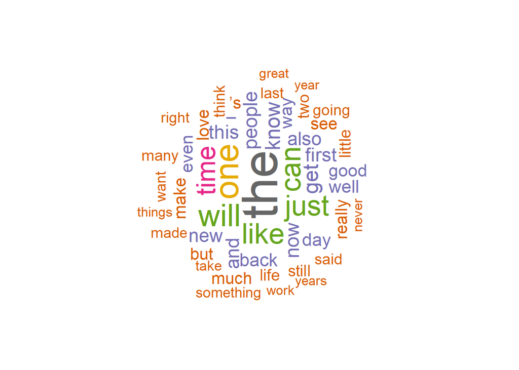

```r
wordcloud(Sub_Blogs, max.words = 50, random.order = FALSE,rot.per=0.35, use.r.layout=FALSE,colors=brewer.pal(8, "Dark2"))
```

News word cloud

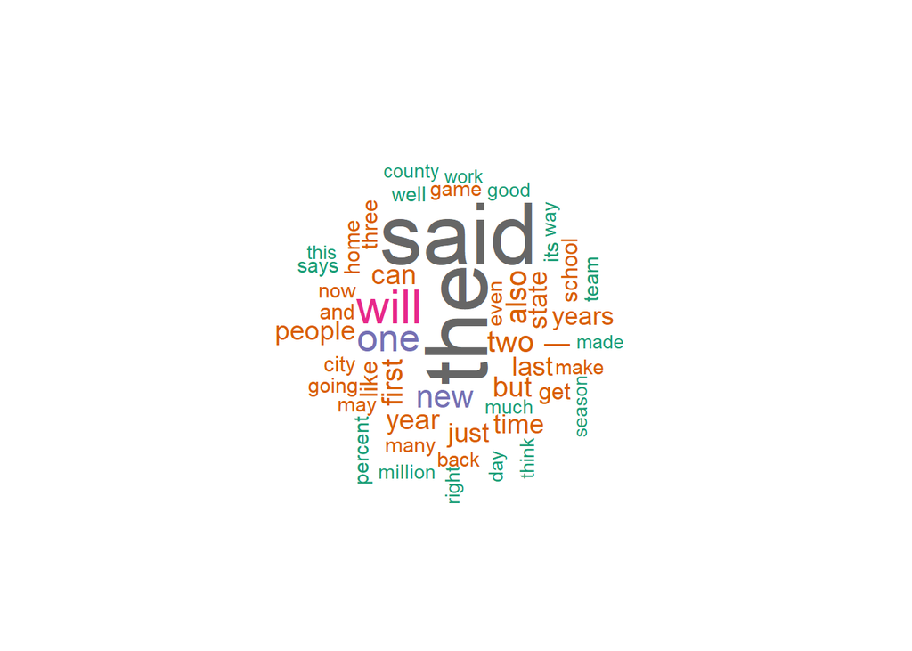

```r
wordcloud(Sub_News, max.words = 50, random.order = FALSE,rot.per=0.35, use.r.layout=FALSE,colors=brewer.pal(8, "Dark2"))
```

Twitter word cloud

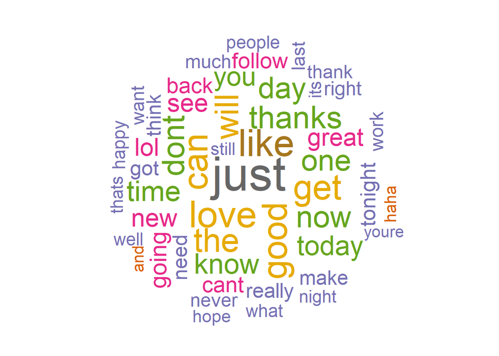

```r
wordcloud(Sub_Twitter, max.words = 50, random.order = FALSE,rot.per=0.35, use.r.layout=FALSE,colors=brewer.pal(8, "Dark2"))
```

Full dataset word cloud

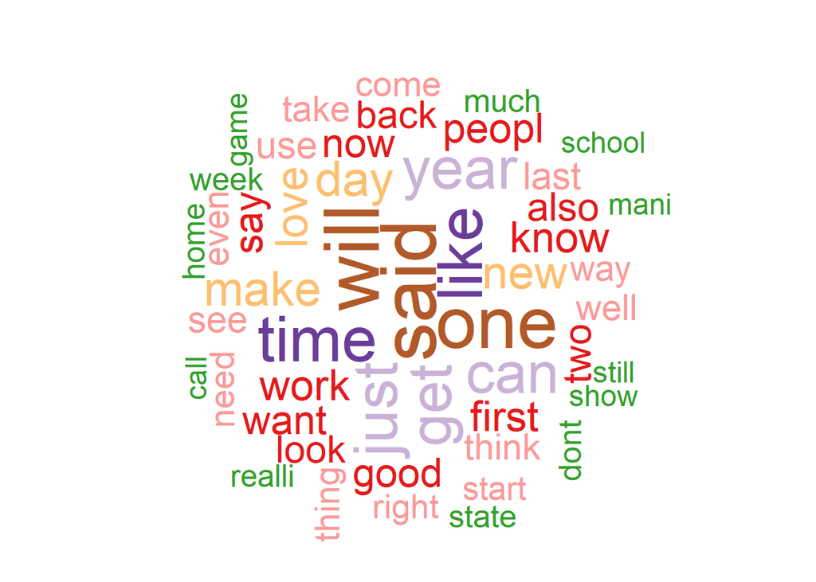

```r
wordcloud(corpus, max.words = 50, random.order = FALSE,rot.per=0.35, use.r.layout=FALSE,colors=brewer.pal(12, "Paired"))
```

Corpus histogram

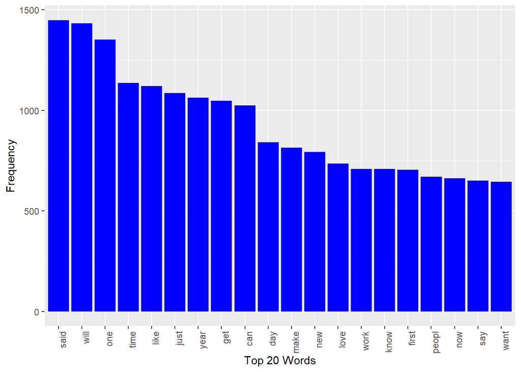

```r
options(mc.cores=1)

corpus_matrix <- TermDocumentMatrix(corpus)

getWordFrequency <- function(tdm) {
  freq <- sort(rowSums(as.matrix(tdm)), decreasing = TRUE)
  return(data.frame(word = names(freq), freq = freq))
}

freq1 <- getWordFrequency(removeSparseTerms(corpus_matrix, 0.99))

ggplot(freq1[1:20,], aes(reorder(word, -freq), freq)) +
    labs(x = "Top 20 Words", y = "Frequency") +
    theme(axis.text.x = element_text(angle = 90, hjust = 1)) +
    geom_bar(stat = "identity", fill = "blue")
```

# Conclusion and Next steps

- From the above word cloud diagrams we can conclude that all 3 datasets have different frequencies for different words.
- Rather than working on whole data date we will be working with the sample dataset to find the second word relation between frequencies with bigrams and trigrams and then apply that to whole dataset.
- we will be building a shinly applicatoin for this.